# VITA12 - Comparison between Mojonnier & Centrifuge Tubes

## Objective

To establish whether the use of Mojonnier flasks can be replaced by centrifuge tubes as part of the VITA12 analysis.

After tidying, the paired data looks like this:

```r
vita12
```

| Analyst | Date | Batch | Sample | Mojonnier | Centrifuge |
| --- | --- | --- | --- | --- | --- |
| JTANIWAN | 42755 | VITA12-17-0012 | IRM001A | 2372 | 2406 |
| JTANIWAN | 42755 | VITA12-17-0012 | 9489860 | 2343 | 1743 |
| JTANIWAN | 42755 | VITA12-17-0012 | 9494808 | 189 | 163 |
| HASSY | 42754 | VITA12-17-0011 | IRM001A | 2328 | 2211 |
| HASSY | 42754 | VITA12-17-0011 | 9482796 | 1960 | 2292 |
| HASSY | 42754 | VITA12-17-0011 | 9483380 | 2105 | 2058 |
| CLOVELL | 42759 | VITA12-17-0014 | IRM001A | 2365 | 2406 |

### Graphing these points

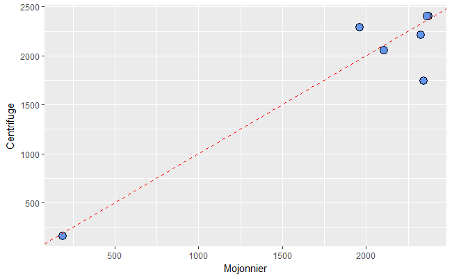

```r
vita_plot
```

The dotted red line is the equivalence point.

### Students t-test, paired

The t-test takes the position that the samples are the same (Ho = there is no difference):

```
    Paired t-test

data:  vita12$Centrifuge and vita12$Mojonnier
t = -0.51795, df = 6, p-value = 0.623
alternative hypothesis: true difference in means is not equal to 0
95 percent confidence interval:
 -313.1971  203.7685
sample estimates:
mean of the differences
              -54.71429
```

The t-test indicates that there is not enough difference between the data sets to reject the null hypothesis, Ho, that there is no difference between the two sets. So far so good.

### TOST Test

The TOST (Two one-sided t-tests) takes the reverse position (Ho = there is a difference between the two sets) and requires an acceptable difference that the user thinks would be insignificant to them. There will always be a difference, what difference can you accept as natural variance?

The nominal acceptable difference has been choosen at 100 although this is clearly too large for the low data set.

```
    Paired TOST

data:  vita12$Centrifuge and vita12$Mojonnier
df = 6
sample estimates:
mean of the differences
              -54.71429

Epsilon: 100
95 percent two one-sided confidence interval (TOST interval):
 -259.9847  150.5561
Null hypothesis of statistical difference is: not rejected
TOST p-value: 0.3415547
```

The TOST test, on the other hand, does not have enough evidence to reject its Ho, that the two sets are different, if the acceptable difference is 100.

The net outcome of this is that there is insufficent data to make a decision.

### IRM001A Comparison

Plotting the batchs for the IRM (IRM001A) gives the following:

```r
 vita12a <- vita %>%
        filter(grepl("IRM001A",Sample))
vita12a$Sample <- "IRM001A"
vita12a <- tidyr::gather(data = vita12a, key = Procedure, value = Result, na.rm = FALSE, Mojonnier, Centrifuge)
vita12a <- vita12a %>%
        arrange(Date) %>%
        na.omit
vita12a
```

| Analyst | Date | Batch | Sample | Procedure | Result |
| --- | --- | --- | --- | --- | --- |
| HASSY | 42754 | VITA12-17-0011 | IRM001A | Mojonnier | 2328 |
| HASSY | 42754 | VITA12-17-0011 | IRM001A | Centrifuge | 2211 |
| HASSY | 42754 | VITA12-17-0011 | IRM001A | Centrifuge | 2427 |
| HASSY | 42754 | VITA12-17-0011 | IRM001A | Centrifuge | 2303 |
| JTANIWAN | 42755 | VITA12-17-0012 | IRM001A | Mojonnier | 2372 |
| JTANIWAN | 42755 | VITA12-17-0012 | IRM001A | Centrifuge | 2406 |
| JTANIWAN | 42755 | VITA12-17-0012 | IRM001A | Centrifuge | 2180 |
| JTANIWAN | 42755 | VITA12-17-0012 | IRM001A | Centrifuge | 2196 |
| CLOVELL | 42759 | VITA12-17-0014 | IRM001A | Mojonnier | 2365 |
| CLOVELL | 42759 | VITA12-17-0014 | IRM001A | Centrifuge | 2406 |

[output cut: 1 more lines]

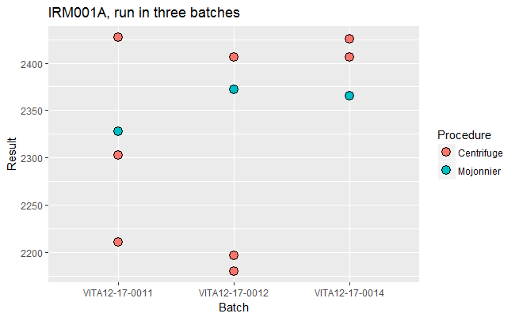

Looking at the above graph, there is clearly a lot more variance in the centrifuge tube results than in the Mojonnier tube results.